# BasicFeaturesExperiments

```
00%|█████████████████████████████████████████████████████████████████████████████████████████████████████████████████████████████████████████████████████████████| 17857/17857 [07:53<00:00, 37.69it/s]
```

```
Extracting CARDINAL named entity frequencies...
```

```
00%|█████████████████████████████████████████████████████████████████████████████████████████████████████████████████████████████████████████████████████████████| 17857/17857 [07:55<00:00, 37.57it/s]
```

```
Extracting PERSON named entity frequencies...
```

```
00%|█████████████████████████████████████████████████████████████████████████████████████████████████████████████████████████████████████████████████████████████| 17857/17857 [07:57<00:00, 37.41it/s]
```

```
Extracting NRC Lexicon POSITIVE emotion scores...
```

```
00%|████████████████████████████████████████████████████████████████████████████████████████████████████████████████████████████████████████████████████████████| 17857/17857 [00:31<00:00, 567.72it/s]
```

```
Extracting NRC Lexicon TRUST emotion scores...
```

```
00%|████████████████████████████████████████████████████████████████████████████████████████████████████████████████████████████████████████████████████████████| 17857/17857 [00:31<00:00, 572.54it/s]
```

```
Extracting Flesch-Kincaid U.S. Grade readability scores...
```

```
00%|███████████████████████████████████████████████████████████████████████████████████████████████████████████████████████████████████████████████████████████| 17857/17857 [00:05<00:00, 3033.00it/s]
```

```
Extracting difficult words readability scores...
```

```
00%|███████████████████████████████████████████████████████████████████████████████████████████████████████████████████████████████████████████████████████████| 17857/17857 [00:04<00:00, 3767.27it/s]
```

```
Extracting normalized capital letter frequency scores..
```

```
00%|████████████████████████████████████████████████████████████████████████████████████████████████████████████████████████████████████████████████████████████| 17857/17857 [00:19<00:00, 930.28it/s]
```

```
Extracting features for Five_Shot_Constraint_Target_basic_features...
Extracting normalized exclamation point frequencies...
```

```
00%|████████████████████████████████████████████████████████████████████████████████████████████████████████████████████████████████████████████████████████████| 53041/53041 [01:09<00:00, 763.42it/s]
```

```
Extracting third person pronoun frequencies...
```

```
00%|████████████████████████████████████████████████████████████████████████████████████████████████████████████████████████████████████████████████████████████| 53041/53041 [01:15<00:00, 706.66it/s]
```

```
Extracting noun-to-verb ratio frequencies...
```

```
00%|█████████████████████████████████████████████████████████████████████████████████████████████████████████████████████████████████████████████████████████████| 53041/53041 [30:15<00:00, 29.21it/s]
```

```
Extracting CARDINAL named entity frequencies...
```

```
00%|█████████████████████████████████████████████████████████████████████████████████████████████████████████████████████████████████████████████████████████████| 53041/53041 [29:46<00:00, 29.69it/s]
```

```
Extracting PERSON named entity frequencies...
```

```
00%|█████████████████████████████████████████████████████████████████████████████████████████████████████████████████████████████████████████████████████████████| 53041/53041 [29:59<00:00, 29.47it/s]
```

```
Extracting NRC Lexicon POSITIVE emotion scores...
```

```
00%|████████████████████████████████████████████████████████████████████████████████████████████████████████████████████████████████████████████████████████████| 53041/53041 [01:59<00:00, 444.43it/s]
```

```
Extracting NRC Lexicon TRUST emotion scores...
```

```
00%|████████████████████████████████████████████████████████████████████████████████████████████████████████████████████████████████████████████████████████████| 53041/53041 [01:59<00:00, 444.95it/s]
```

```
Extracting Flesch-Kincaid U.S. Grade readability scores...
```

```
00%|███████████████████████████████████████████████████████████████████████████████████████████████████████████████████████████████████████████████████████████| 53041/53041 [00:22<00:00, 2326.39it/s]
```

```
Extracting difficult words readability scores...
```

```
00%|███████████████████████████████████████████████████████████████████████████████████████████████████████████████████████████████████████████████████████████| 53041/53041 [00:19<00:00, 2659.77it/s]
```

```
Extracting normalized capital letter frequency scores..
```

```
00%|████████████████████████████████████████████████████████████████████████████████████████████████████████████████████████████████████████████████████████████| 53041/53041 [01:13<00:00, 722.15it/s]
```

```
Extracting features for Five_Shot_PolitiFact_Target_basic_features...
Extracting normalized exclamation point frequencies...
```

```
00%|████████████████████████████████████████████████████████████████████████████████████████████████████████████████████████████████████████████████████████████| 58983/58983 [01:08<00:00, 857.72it/s]
```

```
Extracting third person pronoun frequencies...
```

```
00%|████████████████████████████████████████████████████████████████████████████████████████████████████████████████████████████████████████████████████████████| 58983/58983 [01:14<00:00, 793.71it/s]
```

```
Extracting noun-to-verb ratio frequencies...
```

```
00%|█████████████████████████████████████████████████████████████████████████████████████████████████████████████████████████████████████████████████████████████| 58983/58983 [29:39<00:00, 33.14it/s]
```

```
Extracting CARDINAL named entity frequencies...
```

```
00%|█████████████████████████████████████████████████████████████████████████████████████████████████████████████████████████████████████████████████████████████| 58983/58983 [29:21<00:00, 33.48it/s]
```

```
Extracting PERSON named entity frequencies...
```

```
00%|█████████████████████████████████████████████████████████████████████████████████████████████████████████████████████████████████████████████████████████████| 58983/58983 [29:34<00:00, 33.24it/s]
```

```
Extracting NRC Lexicon POSITIVE emotion scores...
```

```
00%|████████████████████████████████████████████████████████████████████████████████████████████████████████████████████████████████████████████████████████████| 58983/58983 [01:55<00:00, 509.14it/s]
```

```
Extracting NRC Lexicon TRUST emotion scores...
```

```
00%|████████████████████████████████████████████████████████████████████████████████████████████████████████████████████████████████████████████████████████████| 58983/58983 [01:56<00:00, 507.52it/s]
```

```
Extracting Flesch-Kincaid U.S. Grade readability scores...
```

```
00%|███████████████████████████████████████████████████████████████████████████████████████████████████████████████████████████████████████████████████████████| 58983/58983 [00:22<00:00, 2640.00it/s]
```

```
Extracting difficult words readability scores...
```

```
00%|███████████████████████████████████████████████████████████████████████████████████████████████████████████████████████████████████████████████████████████| 58983/58983 [00:19<00:00, 3003.79it/s]
```

```
Extracting normalized capital letter frequency scores..
```

```
00%|████████████████████████████████████████████████████████████████████████████████████████████████████████████████████████████████████████████████████████████| 58983/58983 [01:11<00:00, 822.11it/s]
```

```
Extracting features for Five_Shot_GossipCop_Target_basic_features...
Extracting normalized exclamation point frequencies...
```

```
00%|████████████████████████████████████████████████████████████████████████████████████████████████████████████████████████████████████████████████████████████| 48377/48377 [00:53<00:00, 903.55it/s]
```

```
Extracting third person pronoun frequencies...
```

```
00%|████████████████████████████████████████████████████████████████████████████████████████████████████████████████████████████████████████████████████████████| 48377/48377 [00:57<00:00, 836.68it/s]
```

```
Extracting noun-to-verb ratio frequencies...
```

```
00%|█████████████████████████████████████████████████████████████████████████████████████████████████████████████████████████████████████████████████████████████| 48377/48377 [23:34<00:00, 34.20it/s]
```

```
Extracting CARDINAL named entity frequencies...
```

```
00%|█████████████████████████████████████████████████████████████████████████████████████████████████████████████████████████████████████████████████████████████| 48377/48377 [23:13<00:00, 34.71it/s]
```

```
Extracting PERSON named entity frequencies...
```

```
00%|█████████████████████████████████████████████████████████████████████████████████████████████████████████████████████████████████████████████████████████████| 48377/48377 [23:12<00:00, 34.73it/s]
```

```
Extracting NRC Lexicon POSITIVE emotion scores...
```

```
00%|████████████████████████████████████████████████████████████████████████████████████████████████████████████████████████████████████████████████████████████| 48377/48377 [01:32<00:00, 525.14it/s]
```

```
Extracting NRC Lexicon TRUST emotion scores...
```

```
00%|████████████████████████████████████████████████████████████████████████████████████████████████████████████████████████████████████████████████████████████| 48377/48377 [01:32<00:00, 525.59it/s]
```

```
Extracting Flesch-Kincaid U.S. Grade readability scores...
```

```
00%|███████████████████████████████████████████████████████████████████████████████████████████████████████████████████████████████████████████████████████████| 48377/48377 [00:17<00:00, 2747.76it/s]
```

```
Extracting difficult words readability scores...
```

```
00%|███████████████████████████████████████████████████████████████████████████████████████████████████████████████████████████████████████████████████████████| 48377/48377 [00:15<00:00, 3062.75it/s]
```

```
Extracting normalized capital letter frequency scores..
```

```
00%|████████████████████████████████████████████████████████████████████████████████████████████████████████████████████████████████████████████████████████████| 48377/48377 [00:56<00:00, 851.23it/s]
```

```
Time in seconds elapsed for extracting features for five-shot datasets: 17854.993328094482
```

```python
# Extract the features: zero-shot datasets

start_time_zero_shot = time.time()

# WELFake target
wf_target_zero_shot_train_basic_feature_df = basic_feat_extractor.extractBasicFeatures(
    zero_shot_wf_target_df,
    "Zero_Shot_WELFake_Target_basic_features.csv"
)

# Constraint target
ct_target_zero_shot_train_basic_feature_df = basic_feat_extractor.extractBasicFeatures(
    zero_shot_ct_target_df,
    "Zero_Shot_Constraint_Target_basic_features.csv"
)

# PolitiFact target
pf_target_zero_shot_train_basic_feature_df = basic_feat_extractor.extractBasicFeatures(
    zero_shot_pf_target_df,
    "Zero_Shot_PolitiFact_Target_basic_features.csv"
)

# GossipCop target
gc_target_zero_shot_train_basic_feature_df = basic_feat_extractor.extractBasicFeatures(
    zero_shot_gc_target_df,
    "Zero_Shot_GossipCop_Target_basic_features.csv"
)

end_time_zero_shot = time.time()

time_elapsed_zero_shot = end_time_zero_shot - start_time_zero_shot

print(f"Time in seconds elapsed for extracting features for zero-shot datasets: {time_elapsed_zero_shot}")
```

```
Extracting features for Zero_Shot_WELFake_Target_basic_features...
Extracting normalized exclamation point frequencies...
```

```
00%|████████████████████████████████████████████████████████████████████████████████████████████████████████████████████████████████████████████████████████████| 17852/17852 [00:18<00:00, 975.53it/s]
```

```
Extracting third person pronoun frequencies...
```

```
00%|████████████████████████████████████████████████████████████████████████████████████████████████████████████████████████████████████████████████████████████| 17852/17852 [00:19<00:00, 903.28it/s]
```

```
Extracting noun-to-verb ratio frequencies...
```

```
00%|█████████████████████████████████████████████████████████████████████████████████████████████████████████████████████████████████████████████████████████████| 17852/17852 [07:58<00:00, 37.30it/s]
```

```
Extracting CARDINAL named entity frequencies...
```

```
00%|█████████████████████████████████████████████████████████████████████████████████████████████████████████████████████████████████████████████████████████████| 17852/17852 [08:02<00:00, 36.98it/s]
```

```
Extracting PERSON named entity frequencies...
```

```
00%|█████████████████████████████████████████████████████████████████████████████████████████████████████████████████████████████████████████████████████████████| 17852/17852 [08:01<00:00, 37.09it/s]
```

```
Extracting NRC Lexicon POSITIVE emotion scores...
```

```
00%|████████████████████████████████████████████████████████████████████████████████████████████████████████████████████████████████████████████████████████████| 17852/17852 [00:31<00:00, 571.72it/s]
```

```
Extracting NRC Lexicon TRUST emotion scores...
```

```
00%|████████████████████████████████████████████████████████████████████████████████████████████████████████████████████████████████████████████████████████████| 17852/17852 [00:31<00:00, 572.76it/s]
```

```
Extracting Flesch-Kincaid U.S. Grade readability scores...
```

```
00%|███████████████████████████████████████████████████████████████████████████████████████████████████████████████████████████████████████████████████████████| 17852/17852 [00:05<00:00, 3064.67it/s]
```

```
Extracting difficult words readability scores...
```

```
00%|███████████████████████████████████████████████████████████████████████████████████████████████████████████████████████████████████████████████████████████| 17852/17852 [00:04<00:00, 3798.53it/s]
```

```
Extracting normalized capital letter frequency scores..
```

```
00%|████████████████████████████████████████████████████████████████████████████████████████████████████████████████████████████████████████████████████████████| 17852/17852 [00:18<00:00, 942.09it/s]
```

```
Extracting features for Zero_Shot_Constraint_Target_basic_features...
Extracting normalized exclamation point frequencies...
```

```
00%|████████████████████████████████████████████████████████████████████████████████████████████████████████████████████████████████████████████████████████████| 53036/53036 [01:08<00:00, 774.29it/s]
```

```
Extracting third person pronoun frequencies...
```

```
00%|████████████████████████████████████████████████████████████████████████████████████████████████████████████████████████████████████████████████████████████| 53036/53036 [01:13<00:00, 716.90it/s]
```

```
Extracting noun-to-verb ratio frequencies...
```

```
00%|█████████████████████████████████████████████████████████████████████████████████████████████████████████████████████████████████████████████████████████████| 53036/53036 [30:34<00:00, 28.91it/s]
```

```
Extracting CARDINAL named entity frequencies...
```

```
00%|█████████████████████████████████████████████████████████████████████████████████████████████████████████████████████████████████████████████████████████████| 53036/53036 [30:00<00:00, 29.45it/s]
```

```
Extracting PERSON named entity frequencies...
```

```
00%|█████████████████████████████████████████████████████████████████████████████████████████████████████████████████████████████████████████████████████████████| 53036/53036 [29:52<00:00, 29.59it/s]
```

```
Extracting NRC Lexicon POSITIVE emotion scores...
```

```
00%|████████████████████████████████████████████████████████████████████████████████████████████████████████████████████████████████████████████████████████████| 53036/53036 [01:58<00:00, 447.61it/s]
```

```
Extracting NRC Lexicon TRUST emotion scores...
```

```
00%|████████████████████████████████████████████████████████████████████████████████████████████████████████████████████████████████████████████████████████████| 53036/53036 [01:58<00:00, 448.41it/s]
```

```
Extracting Flesch-Kincaid U.S. Grade readability scores...
```

```
00%|███████████████████████████████████████████████████████████████████████████████████████████████████████████████████████████████████████████████████████████| 53036/53036 [00:22<00:00, 2336.58it/s]
```

```
Extracting difficult words readability scores...
```

```
00%|███████████████████████████████████████████████████████████████████████████████████████████████████████████████████████████████████████████████████████████| 53036/53036 [00:19<00:00, 2652.36it/s]
```

```
Extracting normalized capital letter frequency scores..
```

```
00%|████████████████████████████████████████████████████████████████████████████████████████████████████████████████████████████████████████████████████████████| 53036/53036 [01:12<00:00, 726.62it/s]
```

```
Extracting features for Zero_Shot_PolitiFact_Target_basic_features...
Extracting normalized exclamation point frequencies...
```

```
00%|████████████████████████████████████████████████████████████████████████████████████████████████████████████████████████████████████████████████████████████| 58978/58978 [01:08<00:00, 862.06it/s]
```

```
Extracting third person pronoun frequencies...
```

```
00%|████████████████████████████████████████████████████████████████████████████████████████████████████████████████████████████████████████████████████████████| 58978/58978 [01:14<00:00, 795.34it/s]
```

```
Extracting noun-to-verb ratio frequencies...
```

```
00%|█████████████████████████████████████████████████████████████████████████████████████████████████████████████████████████████████████████████████████████████| 58978/58978 [29:57<00:00, 32.81it/s]
```

```
Extracting CARDINAL named entity frequencies...
```

```
00%|█████████████████████████████████████████████████████████████████████████████████████████████████████████████████████████████████████████████████████████████| 58978/58978 [29:34<00:00, 33.24it/s]
```

```
Extracting PERSON named entity frequencies...
```

```
00%|█████████████████████████████████████████████████████████████████████████████████████████████████████████████████████████████████████████████████████████████| 58978/58978 [29:36<00:00, 33.20it/s]
```

```
Extracting NRC Lexicon POSITIVE emotion scores...
```

```
00%|████████████████████████████████████████████████████████████████████████████████████████████████████████████████████████████████████████████████████████████| 58978/58978 [01:56<00:00, 504.45it/s]
```

```
Extracting NRC Lexicon TRUST emotion scores...
```

```
00%|████████████████████████████████████████████████████████████████████████████████████████████████████████████████████████████████████████████████████████████| 58978/58978 [01:56<00:00, 506.82it/s]
```

```
Extracting Flesch-Kincaid U.S. Grade readability scores...
```

```
00%|███████████████████████████████████████████████████████████████████████████████████████████████████████████████████████████████████████████████████████████| 58978/58978 [00:22<00:00, 2635.22it/s]
```

```
Extracting difficult words readability scores...
```

```
00%|███████████████████████████████████████████████████████████████████████████████████████████████████████████████████████████████████████████████████████████| 58978/58978 [00:19<00:00, 2987.27it/s]
```

```
Extracting normalized capital letter frequency scores..
```

```
00%|████████████████████████████████████████████████████████████████████████████████████████████████████████████████████████████████████████████████████████████| 58978/58978 [01:11<00:00, 823.45it/s]
```

```
Extracting features for Zero_Shot_GossipCop_Target_basic_features...
Extracting normalized exclamation point frequencies...
```

```
00%|████████████████████████████████████████████████████████████████████████████████████████████████████████████████████████████████████████████████████████████| 48372/48372 [00:53<00:00, 902.08it/s]
```

```
Extracting third person pronoun frequencies...
```

```
00%|████████████████████████████████████████████████████████████████████████████████████████████████████████████████████████████████████████████████████████████| 48372/48372 [00:57<00:00, 834.81it/s]
```

```
Extracting noun-to-verb ratio frequencies...
```

```
00%|█████████████████████████████████████████████████████████████████████████████████████████████████████████████████████████████████████████████████████████████| 48372/48372 [23:35<00:00, 34.18it/s]
```

```
Extracting CARDINAL named entity frequencies...
```

```
00%|█████████████████████████████████████████████████████████████████████████████████████████████████████████████████████████████████████████████████████████████| 48372/48372 [23:19<00:00, 34.57it/s]
```

```
Extracting PERSON named entity frequencies...
```

```
00%|█████████████████████████████████████████████████████████████████████████████████████████████████████████████████████████████████████████████████████████████| 48372/48372 [23:40<00:00, 34.04it/s]
```

```
Extracting NRC Lexicon POSITIVE emotion scores...
```

```
00%|████████████████████████████████████████████████████████████████████████████████████████████████████████████████████████████████████████████████████████████| 48372/48372 [01:31<00:00, 525.96it/s]
```

```
Extracting NRC Lexicon TRUST emotion scores...
```

```
00%|████████████████████████████████████████████████████████████████████████████████████████████████████████████████████████████████████████████████████████████| 48372/48372 [01:32<00:00, 522.80it/s]
```

```
Extracting Flesch-Kincaid U.S. Grade readability scores...
```

```
00%|███████████████████████████████████████████████████████████████████████████████████████████████████████████████████████████████████████████████████████████| 48372/48372 [00:17<00:00, 2742.29it/s]
```

```
Extracting difficult words readability scores...
```

```
00%|███████████████████████████████████████████████████████████████████████████████████████████████████████████████████████████████████████████████████████████| 48372/48372 [00:16<00:00, 2953.31it/s]
```

```
Extracting normalized capital letter frequency scores..
```

```
00%|████████████████████████████████████████████████████████████████████████████████████████████████████████████████████████████████████████████████████████████| 48372/48372 [00:57<00:00, 844.01it/s]
```

```
Time in seconds elapsed for extracting features for zero-shot datasets: 17961.79648089409
```

```python
# Extract the features: all 4 datasets combined
all_four_datasets_train_basic_feature_df = basic_feat_extractor.extractBasicFeatures(
    all_four_datasets_train_df,
    "all_four_datasets_train_basic_features.csv"
)

all_four_datasets_val_basic_feature_df = basic_feat_extractor.extractBasicFeatures(
    all_four_datasets_val_df,
    "all_four_datasets_val_basic_features.csv"
)
```

```
Extracting features for all_four_datasets_train_basic_features...
Extracting normalized exclamation point frequencies...
```

```
00%|████████████████████████████████████████████████████████████████████████████████████████████████████████████████████████████████████████████████████████████| 59414/59414 [01:07<00:00, 879.73it/s]
```

```
Extracting third person pronoun frequencies...
```

```
00%|████████████████████████████████████████████████████████████████████████████████████████████████████████████████████████████████████████████████████████████| 59414/59414 [01:15<00:00, 791.82it/s]
```

```
Extracting noun-to-verb ratio frequencies...
```

```
00%|█████████████████████████████████████████████████████████████████████████████████████████████████████████████████████████████████████████████████████████████| 59414/59414 [31:39<00:00, 31.27it/s]
```

```
Extracting CARDINAL named entity frequencies...
```

```
00%|█████████████████████████████████████████████████████████████████████████████████████████████████████████████████████████████████████████████████████████████| 59414/59414 [31:06<00:00, 31.83it/s]
```

```
Extracting PERSON named entity frequencies...
```

```
00%|█████████████████████████████████████████████████████████████████████████████████████████████████████████████████████████████████████████████████████████████| 59414/59414 [30:19<00:00, 32.66it/s]
```

```
Extracting NRC Lexicon POSITIVE emotion scores...
```

```
00%|████████████████████████████████████████████████████████████████████████████████████████████████████████████████████████████████████████████████████████████| 59414/59414 [01:59<00:00, 496.39it/s]
```

```
Extracting NRC Lexicon TRUST emotion scores...
```

```
00%|████████████████████████████████████████████████████████████████████████████████████████████████████████████████████████████████████████████████████████████| 59414/59414 [01:59<00:00, 495.77it/s]
```

```
Extracting Flesch-Kincaid U.S. Grade readability scores...
```

```
00%|███████████████████████████████████████████████████████████████████████████████████████████████████████████████████████████████████████████████████████████| 59414/59414 [00:22<00:00, 2607.67it/s]
```

```
Extracting difficult words readability scores...
```

```
00%|███████████████████████████████████████████████████████████████████████████████████████████████████████████████████████████████████████████████████████████| 59414/59414 [00:20<00:00, 2934.06it/s]
```

```
Extracting normalized capital letter frequency scores..
```

```
00%|████████████████████████████████████████████████████████████████████████████████████████████████████████████████████████████████████████████████████████████| 59414/59414 [01:14<00:00, 802.06it/s]
```

```
Extracting features for all_four_datasets_val_basic_features...
Extracting normalized exclamation point frequencies...
```

```
00%|████████████████████████████████████████████████████████████████████████████████████████████████████████████████████████████████████████████████████████████| 14187/14187 [00:15<00:00, 889.52it/s]
```

```
Extracting third person pronoun frequencies...
```

```
00%|████████████████████████████████████████████████████████████████████████████████████████████████████████████████████████████████████████████████████████████| 14187/14187 [00:17<00:00, 816.71it/s]
```

```
Extracting noun-to-verb ratio frequencies...
```

```
00%|█████████████████████████████████████████████████████████████████████████████████████████████████████████████████████████████████████████████████████████████| 14187/14187 [06:50<00:00, 34.60it/s]
```

```
Extracting CARDINAL named entity frequencies...
```

```
00%|█████████████████████████████████████████████████████████████████████████████████████████████████████████████████████████████████████████████████████████████| 14187/14187 [06:49<00:00, 34.64it/s]
```

```
Extracting PERSON named entity frequencies...
```

```
00%|█████████████████████████████████████████████████████████████████████████████████████████████████████████████████████████████████████████████████████████████| 14187/14187 [06:50<00:00, 34.57it/s]
```

```
Extracting NRC Lexicon POSITIVE emotion scores...
```

```
00%|████████████████████████████████████████████████████████████████████████████████████████████████████████████████████████████████████████████████████████████| 14187/14187 [00:27<00:00, 519.53it/s]
```

```
Extracting NRC Lexicon TRUST emotion scores...
```

```
00%|████████████████████████████████████████████████████████████████████████████████████████████████████████████████████████████████████████████████████████████| 14187/14187 [00:27<00:00, 518.88it/s]
```

```
Extracting Flesch-Kincaid U.S. Grade readability scores...
```

```
00%|███████████████████████████████████████████████████████████████████████████████████████████████████████████████████████████████████████████████████████████| 14187/14187 [00:05<00:00, 2750.39it/s]
```

```
Extracting difficult words readability scores...
```

```
00%|███████████████████████████████████████████████████████████████████████████████████████████████████████████████████████████████████████████████████████████| 14187/14187 [00:04<00:00, 3088.79it/s]
```

```
Extracting normalized capital letter frequency scores..
```

```
00%|████████████████████████████████████████████████████████████████████████████████████████████████████████████████████████████████████████████████████████████| 14187/14187 [00:16<00:00, 842.61it/s]
```

## Combining TF-IDF with New Features and Hyperparamater Tuning with Bayesian Optimization

```python
# Collect the training datasets with extra features into a list
feature_train_datasets_for_hyperparameter_optimization = [
    wf_train_basic_feature_df,
    fe_train_basic_feature_df,
    ct_train_basic_feature_df,
    pf_train_basic_feature_df,
    gc_train_basic_feature_df,
    wf_target_five_shot_train_basic_feature_df,
    ct_target_five_shot_train_basic_feature_df,
    pf_target_five_shot_train_basic_feature_df,
    gc_target_five_shot_train_basic_feature_df,
    wf_target_zero_shot_train_basic_feature_df,
    ct_target_zero_shot_train_basic_feature_df,
    pf_target_zero_shot_train_basic_feature_df,
    gc_target_zero_shot_train_basic_feature_df
]

# Collect dataset descriptions in a list
feature_train_dataset_names_for_hyperparameter_optimization = [
    "WELFake",
    "Fakeddit",
    "Constraint",
    "PolitiFact",
    "GossipCop",
    "Five_Shot_WELFake_Target",
    "Five_Shot_Constraint_Target",
    "Five_Shot_PolitiFact_Target",
    "Five_Shot_GossipCop_Target",
    "Zero_Shot_WELFake_Target",
    "Zero_Shot_Constraint_Target",
    "Zero_Shot_PolitiFact_Target",
    "Zero_Shot_GossipCop_Target"
]

# Get column names of the extra features
extra_feature_columns = [
    "exclamation_point_frequency", "third_person_pronoun_frequency", "noun_to_verb_ratio",
    "cardinal_named_entity_frequency", "person_named_entity_frequency",
    "nrc_positive_emotion_score", "nrc_trust_emotion_score",
    "flesch_kincaid_readability_score", "difficult_words_readability_score",
    "capital_letter_frequency"
]


def optimizeHyperparameters(
    df, dataset_name, hyperparameter_grid,
    extra_feature_columns, root_path,
    num_bayes_iterations=50, cv=3
):
    """
        A function that takes in a single news DataFrame containing a "text" column and a set of
        custom engineered numerical feature columns, as well as a list of these extra column
        names and a grid of hyperparameters to tune for the TF-IDF vectorizer and Passive
        Aggressive classifier pipeline that will be constructed in the function. It
        uses Bayesian Optimization and cross-validation (by default, 3) with 50 iterations
        by default to tune the pipeline's hyperparameters. It then stores the optimal
        hyperparameters and best F1-score to a DataFrame and .csv file.

        Input Parameters:
            df (pd DataFrame): pandas DataFrame containing news texts, fake/real news labels,
                and extra features
            dataset_name (str): name of the dataset (for Index in resulting DF and saving)
            hyperparameter_grid (dict): search space for specific hyperparameters
            extra_feature_columns (list): list of the names of the columns storing
                                          the new extra features
            root_path (str): folder to save the results in
            num_bayes_iterations (int): number of times to try new param combinations
            cv (int): number of cross-validation folds to use in optimizer

        Output:
            results_df (pd Dataframe): pandas DataFrame storing best hyperparam configuration
                                       and F1-score

    """

    # Create an list to store the optimal hyperparameter results
    results = []

    print(f"Optimizing hyperparameters for {dataset_name}...")

    # Instantiate a TF-IDF vectorizer object
    tfidf_vectorizer = TfidfVectorizer(
        ngram_range=(1, 3),  # Include unigrams, bigrams and trigrams
        strip_accents="unicode" # Remove accents and perform other character normalization during the preprocessing step
    )

    # Combine the TF-IDF features and manual features using ColumnTransformer
    # Ref: https://scikit-learn.org/1.5/modules/generated/sklearn.compose.ColumnTransformer.html
    """
        The ColumnTransformer class allows different columns or column subsets of the input to be transformed separately
        and the features generated by each transformer will be concatenated to form a single feature space.
        This is useful for heterogeneous or columnar data, to combine several feature extraction mechanisms or
        transformations into a single transformer.
    """
    col_transformer = ColumnTransformer(
        # Specifying the transformer objects to be applied to subsets of the data.
        transformers=[
            ("tfidf", tfidf_vectorizer, "text"),  # Apply TF-IDF on the "text" column
            # Scale extra features to stop larger ones dominating the classifier and gather the column names into a list
            ("extra_features", StandardScaler(), extra_feature_columns)
        ],
        remainder="drop"  # Drop any unused columns such as IDs or labels
    )

    # Define a fresh new model: Passive-Aggressive Classifier
    pac_model = PassiveAggressiveClassifier(random_state=5)

    # Create the pipeline with TF-IDF and extra features extraction and then the calibrated PassiveAgressive Classifier model
    pipeline = Pipeline(steps=[
        ("col_transformer", col_transformer),
        ("pac_model", pac_model)
    ])

    # Define the Bayesian optimizer
    bayesian_optimizer = BayesSearchCV(
        estimator=pipeline,
        search_spaces=hyperparameter_grid,
        n_iter=num_bayes_iterations,  # Number of iterations
        cv=cv,       # 3-fold cross-validation (trade-off between time required and performance)
        scoring=make_scorer(f1_score, average="macro"),  # A scorer is a wrapper around an arbitrary metric: wrap around F1
        verbose=1, # Made this go from 3 to 1 as too many print outs
        n_jobs=-1,  # Use all available cores
        random_state=5
    )

     # Extract the 'text' column and the extra feature columns
    X = df[["text"] + extra_feature_columns]  # Select only the relevant columns
    y = df["label"] # Extract real and fake news labels

    # Fit the Bayesian optimizer to the dataset
    bayesian_optimizer.fit(X, y)

    # Extract the best hyperparameters and best score
    best_params = bayesian_optimizer.best_params_
    best_score = bayesian_optimizer.best_score_

    # Append the results for this dataset
    results.append({
        "Dataset": dataset_name,
        "Best Hyperparameters": best_params,
        "Best Macro F1-Score": best_score
    })

    # Convert the results into a pandas DataFrame
    results_df = pd.DataFrame(results)

    # Save the results to a CSV file
    results_df = results_df.set_index("Dataset")
    results_df.to_csv(os.path.join(root_path, f"optimized_hyperparameters_{dataset_name}.csv"))

    print(f"Optimization complete. Results saved to 'optimized_hyperparameters_{dataset_name}.csv'")

    return results_df


def optimizeHyperparamsForMultipleDFs(
    datasets, dataset_names, root_path,
    hyperparameter_grid, extra_feature_columns,
    num_bayes_iterations=50, cv=3
):
    """
        A function that loops over a list of pandas DataFrames and their descriptions
        and runs the previous function to save and output the best set of
        hyperparameters found for them with Bayesian Optimization.

        Input Parameters:
            datasets (list of pandas DataFrames): list of DFs to find best params for
            dataset_names (list of str): dataset names
            root_path (str): folder to save the results in
            hyperparameter_grid (dict): search space for specific hyperparameters
            extra_feature_columns (list): list of the names of the columns storing
                                          the new extra features

            num_bayes_iterations (int): number of times to try new param combinations
            cv (int): number of cross-validation folds to use in optimizer

        Output:
            results_concat_df (pd Dataframe): pandas DataFrame storing best hyperparams
                                       and F1-scores for all the DataFrames inserted

    """
    start_time = time.time()
    all_results = []  # List to collect all the results

    for df, dataset_name in zip(datasets, dataset_names): # Zip up pairs of DataFrames and their names/descriptions
        # Call the optimizeHyperparameters function and get the results dataframe
        results_df = optimizeHyperparameters(
                                                df, dataset_name, hyperparameter_grid, extra_feature_columns,
                                                root_path, num_bayes_iterations, cv)

        # Append the results to the all_results list
        all_results.append(results_df)

    results_concat_df = pd.concat(all_results)

    # Save the concatenated results to a CSV file
    results_concat_df.to_csv(os.path.join(root_path, "optimized_hyperparameters_all_datasets.csv"))

    end_time = time.time()

    total_time_elapsed = end_time - start_time

    # Convert time to hours, minutes, seconds by using "divmod" to get the quotient and remainder for further calculatios
    hours, remainder = divmod(total_time_elapsed, 3600) # Divide by 60*60 to get hours from seconds and remainder will be minutes
    minutes, seconds = divmod(remainder, 60)

    print(f"Total time elapsed: {int(hours)}:{int(minutes)}:{int(seconds)}")

    return results_concat_df
```

```python
root_path = "../FPData/BasicFeaturesHyperparameterOptimizationResults"
num_datasets = len(feature_train_datasets_for_hyperparameter_optimization)

# Hyperparameter grid with search space to go through with Bayesian Optimization
param_grid = {
    "col_transformer__tfidf__max_df": Real(0.7, 1.0, prior="uniform"),
    "col_transformer__tfidf__min_df": Integer(1, 10),
    "col_transformer__tfidf__max_features": Integer(1000, 50000),
    "pac_model__C": Real(0.1, 10.0, prior="log-uniform"),
    "pac_model__loss": Categorical(['hinge', 'squared_hinge'])
}

print(f"Starting hyperparameter optimization across {num_datasets} datasets...")

hyperparameter_optimization_results_df = optimizeHyperparamsForMultipleDFs(
        feature_train_datasets_for_hyperparameter_optimization,
        feature_train_dataset_names_for_hyperparameter_optimization,
        root_path,
        param_grid,
        extra_feature_columns,
        num_bayes_iterations=50,
        cv=3  # Using 3-fold CV as in your original code
    )

print(f"\nFinished hyperparameter optimization! Results for all the datasets have been saved in the {root_path} directory.")
```

[output not shown]

[output cut: 1587 more lines]

[output not shown]

[output cut: 965 more lines]

```python
# Extract the "Best Hyperparameters" column into separate columns in a new DataFrame
hyperparams_df = pd.json_normalize(hyperparameter_optimization_results_df["Best Hyperparameters"])

# Set the expanded hyperparameter DataFrame index to the dataset names from the original DataFrame hyperparameter_optimization_results_df
hyperparams_df = hyperparams_df.set_index(hyperparameter_optimization_results_df.index)

# Set the best macro f1-score column to that of the original hyperparameter_optimization_results_df DataFrame
hyperparams_df["Best Macro F1-Score"] = hyperparameter_optimization_results_df["Best Macro F1-Score"]

hyperparams_df
```

| Dataset | col_transformer__tfidf__max_df | col_transformer__tfidf__max_features | col_transformer__tfidf__min_df | pac_model__C | pac_model__loss | Best Macro F1-Score |
| --- | --- | --- | --- | --- | --- | --- |
| WELFake | 0.707865 | 47729 | 10 | 0.184437 | hinge | 0.955592 |
| Fakeddit | 1.000000 | 34451 | 1 | 0.100000 | hinge | 0.842224 |
| Constraint | 1.000000 | 36302 | 1 | 10.000000 | hinge | 0.937198 |
| PolitiFact | 0.898211 | 10213 | 4 | 0.633719 | squared_hinge | 0.880669 |
| GossipCop | 0.923629 | 41210 | 9 | 0.610721 | hinge | 0.766085 |
| Five_Shot_WELFake_Target | 0.742179 | 49869 | 10 | 0.101436 | squared_hinge | 0.828257 |
| Five_Shot_Constraint_Target | 1.000000 | 50000 | 1 | 0.100000 | squared_hinge | 0.903334 |
| Five_Shot_PolitiFact_Target | 1.000000 | 50000 | 10 | 0.100000 | squared_hinge | 0.898885 |
| Five_Shot_GossipCop_Target | 1.000000 | 50000 | 10 | 0.100000 | squared_hinge | 0.940716 |
| Zero_Shot_WELFake_Target | 0.968433 | 49949 | 2 | 4.527808 | hinge | 0.832087 |
| Zero_Shot_Constraint_Target | 1.000000 | 50000 | 1 | 0.100000 | squared_hinge | 0.905636 |
| Zero_Shot_PolitiFact_Target | 0.800923 | 49973 | 2 | 1.176437 | squared_hinge | 0.899930 |
| Zero_Shot_GossipCop_Target | 0.769888 | 49972 | 8 | 9.760765 | hinge | 0.940966 |

```python
# Optimize for four-dataset combined DataFrame
all_four_sets_combined_hyperparams = optimizeHyperparameters(
    all_four_datasets_train_basic_feature_df, "All_Four_Combined", param_grid,
    extra_feature_columns, root_path,
    num_bayes_iterations=50, cv=3
)
```

[output not shown]

## Evaluating the Model with Optimized Hyperparameters on the Validation Sets

```python
def trainModel(train_df, extra_feature_columns, best_hyperparameters):
    """
    Train a single Passive-Aggressive Classifier model on a given dataset/DataFrame
    using both TF-IDF and the additional extracted features, to use for evaluation
    on the validation sets.

    Parameters:
        df (pd.DataFrame): DataFrame containing the dataset with a "text" column and columns for extra features.
        extra_feature_columns (list): List of column names for extra features.
        best_hyperparameters (dict): Dictionary containing the best hyperparameters for the model and pipeline.

    Returns:
        trained_pipeline (Pipeline): Trained pipeline including TF-IDF, features from feature engineering and the PAC model.
    """

    # Configure and instantiate TF-IDF vectorizer
    tfidf_vectorizer = TfidfVectorizer(
        ngram_range=(1, 3),  # Include unigrams, bigrams, and trigrams
        strip_accents="unicode",  # Remove accents
        max_df=best_hyperparameters.get("col_transformer__tfidf__max_df", 1.0), # Default to 1 (no threshold)
        min_df=best_hyperparameters.get("col_transformer__tfidf__min_df", 1),
        max_features=best_hyperparameters.get("col_transformer__tfidf__max_features", None) # Include all features as backup option
    )

    # Combine TF-IDF and extra features in a ColumnTransformer
    col_transformer = ColumnTransformer(
        transformers=[
            ("tfidf", tfidf_vectorizer, "text"),
            ("extra_features", StandardScaler(), extra_feature_columns)
        ],
        remainder="drop"
    )

    # Define Passive-Aggressive Classifier with best hyperparameters
    pac_model = PassiveAggressiveClassifier(
        C=best_hyperparameters.get("pac_model__C", 0.1),
        loss=best_hyperparameters.get("pac_model__loss", "hinge"),
        random_state=5
    )

    # Create a pipeline
    pipeline = Pipeline(steps=[
        ("col_transformer", col_transformer),
        ("pac_model", pac_model)
    ])

    # Extract features and labels
    X = train_df[["text"] + extra_feature_columns]  # Select the text and extra feature columns
    y = train_df["label"]  # Extract the labels

    # Train the pipeline
    print("Training the model...")
    pipeline.fit(X, y)
    print("Model training complete.")

    return pipeline
```

```python
def classifierEvaluation(y_test, y_pred, dataset_name, average_type="macro", cmap="viridis"):
  """
    Function for evaluating classifier performance using different metrics.
    Input Parameters:
      y_test (list): list of ground truth fake news labels (0 = real, 1 = fake)
      y_pred (list): list of predicted labels
      average_type (str): determines whether to use macro or micro evaluation metrics, macro is better when classes are imbalanced to gauge performance on minority
      cmap (str): matplotlib colormap for Seaborn-generated confusion matrix
    Output:
      dictionary storing scores for 4 evaluation metrics
  """

  # Calculate the basic metrics
  accuracy = accuracy_score(y_test, y_pred)
  precision = precision_score(y_test, y_pred, average=average_type) # use macro due to class imbalance, to represent performance across all classes esp. minority class
  recall = recall_score(y_test, y_pred, average=average_type)
  macro_f1 = f1_score(y_test, y_pred, average=average_type)

  # Print the results
  print(f"Accuracy: {accuracy:.4f}")
  print(f"Precision (Macro): {precision:.4f}")
  print(f"Recall (Macro): {recall:.4f}")
  print(f"Macro F1-score: {macro_f1:.4f}")

  # Print the classification report
  print("\nClassification Report:\n")
  print(classification_report(y_test, y_pred))

  # Generate a confusion matrix
  c_matrix = confusion_matrix(y_test, y_pred)

  # Visualize confusion matrix using Seaborn heatmap
  plt.figure(figsize=(6, 5)) # Set figure size
  sns.heatmap(c_matrix, annot=True, fmt='d', cmap=cmap, # fmt = 'd' means output integers for the counts
            xticklabels=["real", "fake"], yticklabels=['real', 'fake']) # Map 0 = real, 1 = fake
  plt.title(f"Confusion Matrix for {dataset_name}")
  plt.xlabel("Predicted Class")
  plt.ylabel("Ground Truth")
  plt.show()

  return {"accuracy": accuracy, "precision": precision, "recall": recall, "macro_f1": macro_f1}
```

```python
def evaluateModel(pipeline, val_df, extra_feature_columns, dataset_name):
    """
    Evaluate a pre-trained pipeline/model on a validation dataset.

    Parameters:
        pipeline (Pipeline): The trained sklearn pipeline/model.
        validation_df (pd.DataFrame): A pandas DataFrame containing the validation set
                                      with a "text" column and extra features.
        extra_feature_columns (list): List of column names for the extra features.

    Returns:
        dict: A dictionary containing evaluation metrics including accuracy, precision,
              recall, and F1-score.
    """

    # Extract the features and labels from the validation dataframe
    X_val = val_df[["text"] + extra_feature_columns]  # Combine text and extra features
    y_val = val_df["label"]  # Ground truth labels # Make predictions using the trained pipeline

    y_pred = pipeline.predict(X_val)

    eval_dict = classifierEvaluation(y_val, y_pred, dataset_name, average_type="macro", cmap="viridis")

    return eval_dict
```

### Full-Scale Scenario Training and Evaluation on Validation Sets (Same Dataset for Train and Val Sets)

```
Training the model...
Model training complete.
Accuracy: 0.9635
Precision (Macro): 0.9616
Recall (Macro): 0.9635
Macro F1-score: 0.9625

Classification Report:

              precision    recall  f1-score   support

           0       0.97      0.96      0.97      5463
           1       0.95      0.96      0.96      3862

    accuracy                           0.96      9325
   macro avg       0.96      0.96      0.96      9325
weighted avg       0.96      0.96      0.96      9325
```

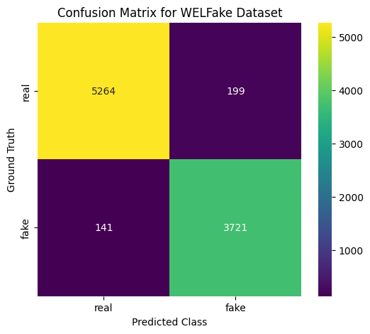

```python
# Train model with optimal hyperparams for WELFake training set and evaluate on WELFake validation set
wf_model = trainModel(
    wf_train_basic_feature_df, # WELfake training set
    extra_feature_columns, # List of extra feature column names for Column Transformer extraction
    dict(hyperparameter_optimization_results_df.loc["WELFake", "Best Hyperparameters"]) # Pass in best params as dict
)

wf_eval_dict = evaluateModel(wf_model, wf_val_basic_feature_df, extra_feature_columns, "WELFake Dataset")
```

```
Training the model...
Model training complete.
Accuracy: 0.8403
Precision (Macro): 0.8395
Recall (Macro): 0.8356
Macro F1-score: 0.8372

Classification Report:

              precision    recall  f1-score   support

           0       0.84      0.88      0.86     39299
           1       0.83      0.80      0.81     31033

    accuracy                           0.84     70332
   macro avg       0.84      0.84      0.84     70332
weighted avg       0.84      0.84      0.84     70332
```

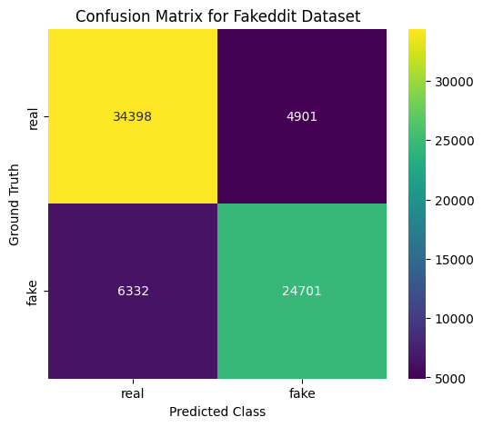

```python
# Train model with optimal hyperparams for Fakeddit training set and evaluate on Fakeddit validation set
fe_model = trainModel(
    fe_train_basic_feature_df, # Fakeddit training set
    extra_feature_columns, # List of extra feature column names for Column Transformer extraction
    dict(hyperparameter_optimization_results_df.loc["Fakeddit", "Best Hyperparameters"]) # Pass in best params as dict
)

fe_eval_dict = evaluateModel(fe_model, fe_val_basic_feature_df, extra_feature_columns, "Fakeddit Dataset")
```

```
Training the model...
Model training complete.
Accuracy: 0.9464
Precision (Macro): 0.9468
Recall (Macro): 0.9459
Macro F1-score: 0.9463

Classification Report:

              precision    recall  f1-score   support

           0       0.94      0.96      0.95      1116
           1       0.95      0.93      0.94      1012

    accuracy                           0.95      2128
   macro avg       0.95      0.95      0.95      2128
weighted avg       0.95      0.95      0.95      2128
```

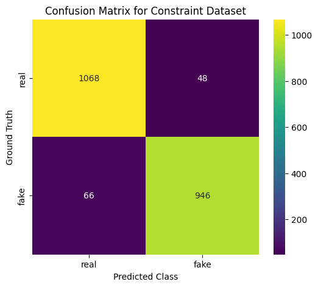

```python
# Train model with optimal hyperparams for Constraint training set and evaluate on Constraint validation set
ct_model = trainModel(
    ct_train_basic_feature_df, # Constraint training set
    extra_feature_columns, # List of extra feature column names for Column Transformer extraction
    dict(hyperparameter_optimization_results_df.loc["Constraint", "Best Hyperparameters"]) # Pass in best params as dict
)

ct_eval_dict = evaluateModel(ct_model, ct_val_basic_feature_df, extra_feature_columns, "Constraint Dataset")
```

```
Training the model...
Model training complete.
Accuracy: 0.8942
Precision (Macro): 0.8942
Recall (Macro): 0.9015
Macro F1-score: 0.8937

Classification Report:

              precision    recall  f1-score   support

           0       0.96      0.85      0.90        59
           1       0.83      0.96      0.89        45

    accuracy                           0.89       104
   macro avg       0.89      0.90      0.89       104
weighted avg       0.90      0.89      0.89       104
```

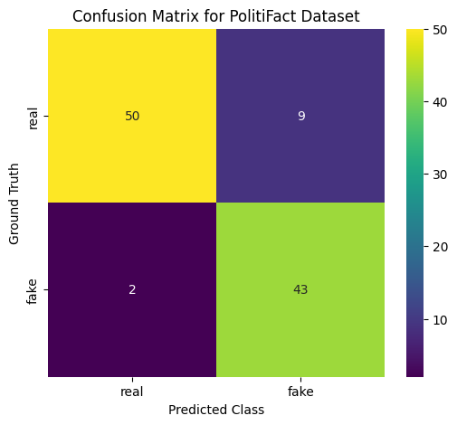

```python
# Train model with optimal hyperparams for PolitiFact training set and evaluate on PolitiFact validation set
pf_model = trainModel(
    pf_train_basic_feature_df, # PolitiFact training set
    extra_feature_columns, # List of extra feature column names for Column Transformer extraction
    dict(hyperparameter_optimization_results_df.loc["PolitiFact", "Best Hyperparameters"]) # Pass in best params as dict
)

pf_eval_dict = evaluateModel(pf_model, pf_val_basic_feature_df, extra_feature_columns, "PolitiFact Dataset")
```

```
Training the model...
Model training complete.
Accuracy: 0.8483
Precision (Macro): 0.7991
Recall (Macro): 0.7503
Macro F1-score: 0.7696

Classification Report:

              precision    recall  f1-score   support

           0       0.88      0.93      0.90      2018
           1       0.72      0.57      0.63       612

    accuracy                           0.85      2630
   macro avg       0.80      0.75      0.77      2630
weighted avg       0.84      0.85      0.84      2630
```

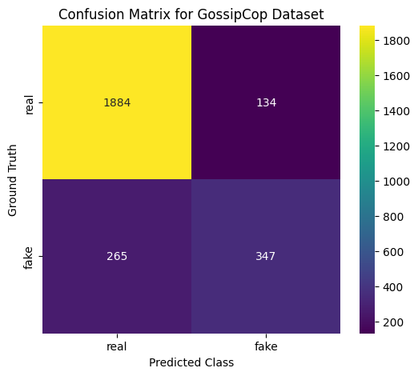

```python
# Train model with optimal hyperparams for GossipCop training set and evaluate on GossipCop validation set
gc_model = trainModel(
    gc_train_basic_feature_df, # GossipCop training set
    extra_feature_columns, # List of extra feature column names for Column Transformer extraction
    dict(hyperparameter_optimization_results_df.loc["GossipCop", "Best Hyperparameters"]) # Pass in best params as dict
)

gc_eval_dict = evaluateModel(gc_model, gc_val_basic_feature_df, extra_feature_columns, "GossipCop Dataset")
```

## Training on all 4 Text-Based Datasets (WELFake, Constraint, PolitiFact, GossipCop) from Different Domains and Evaluating on the Same 4 Datasets' Validation Splits, Concatenated

```python
all_four_sets_model = trainModel(
    all_four_datasets_train_basic_feature_df, # All 4 text-based datasets combined
    extra_feature_columns, # List of extra feature column names for Column Transformer extraction
    dict(all_four_sets_combined_hyperparams.loc["All_Four_Combined", "Best Hyperparameters"]) # Pass in best params as dict
)
```

```
Training the model...
Model training complete.
```

```
Accuracy: 0.9016
Precision (Macro): 0.8969
Recall (Macro): 0.8960
Macro F1-score: 0.8965

Classification Report:

              precision    recall  f1-score   support

           0       0.92      0.92      0.92      8656
           1       0.88      0.87      0.87      5531

    accuracy                           0.90     14187
   macro avg       0.90      0.90      0.90     14187
weighted avg       0.90      0.90      0.90     14187
```

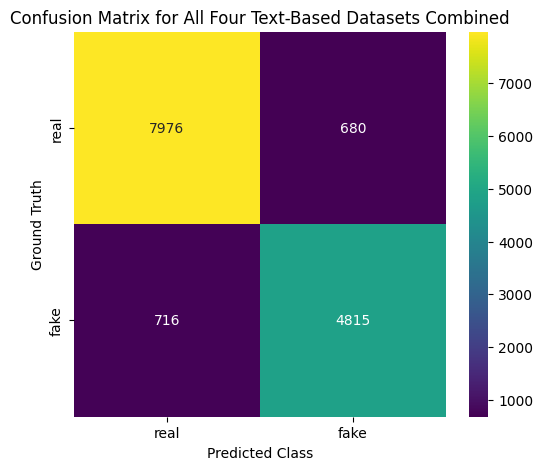

```python
# Evaluate on all four validation sets combined
all_four_sets_model_eval_dict = evaluateModel(all_four_sets_model, all_four_datasets_val_basic_feature_df,
                                              extra_feature_columns,
                                             "All Four Text-Based Datasets Combined"
                                             )
```

This model is the one which will be used for user testing LIME-based explanations in the Streamlit applications, as it draws on a combination of all the long-form (therefore NOT Fakeddit) datasets and receives a decent macro-average F1-score on all those four datasets' validation splits (90%).

### Five-Shot Scenario Evaluation (3 Source Combined Datasets for Training + 5 Random Samples from Target Dataset, Evaluation on Validation Set from Left-Out Dataset)

```
Training the model...
Model training complete.
Accuracy: 0.6253
Precision (Macro): 0.6093
Recall (Macro): 0.6024
Macro F1-score: 0.6030

Classification Report:

              precision    recall  f1-score   support

           0       0.66      0.74      0.70      5463
           1       0.56      0.47      0.51      3862

    accuracy                           0.63      9325
   macro avg       0.61      0.60      0.60      9325
weighted avg       0.62      0.63      0.62      9325
```

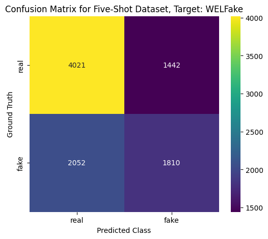

```python
# Train model with optimal hyperparams on five-shot mixed dataset with WELFake contributing only 5 samples
five_shot_target_wf_model = trainModel(
    wf_target_five_shot_train_basic_feature_df, # WELFake target five-shot training set
    extra_feature_columns, # List of extra feature column names for Column Transformer extraction
    dict(hyperparameter_optimization_results_df.loc["Five_Shot_WELFake_Target", "Best Hyperparameters"]) # Pass in best params as dict
)

# Evaluate on WELFake validation set
five_shot_target_wf_eval_dict = evaluateModel(five_shot_target_wf_model, wf_val_basic_feature_df, extra_feature_columns,
                                             "Five-Shot Dataset, Target: WELFake")
```

```
Training the model...
Model training complete.
Accuracy: 0.4328
Precision (Macro): 0.4038
Recall (Macro): 0.4496
Macro F1-score: 0.3677

Classification Report:

              precision    recall  f1-score   support

           0       0.36      0.11      0.16      1116
           1       0.45      0.79      0.57      1012

    accuracy                           0.43      2128
   macro avg       0.40      0.45      0.37      2128
weighted avg       0.40      0.43      0.36      2128
```

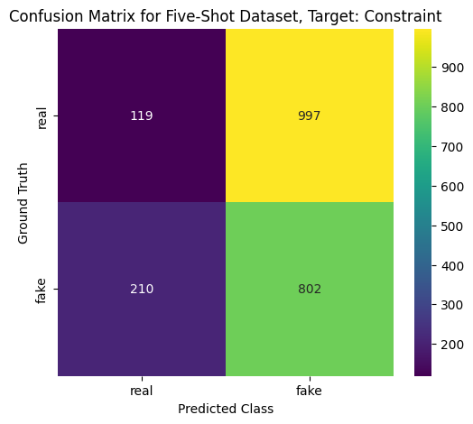

```python
# Train model with optimal hyperparams on five-shot mixed dataset with Constraint contributing only 5 samples
five_shot_target_ct_model = trainModel(
    ct_target_five_shot_train_basic_feature_df, # Constraint target five-shot training set
    extra_feature_columns, # List of extra feature column names for Column Transformer extraction
    dict(hyperparameter_optimization_results_df.loc["Five_Shot_Constraint_Target", "Best Hyperparameters"]) # Pass in best params as dict
)

# Evaluate on Constraint validation set
five_shot_target_ct_eval_dict = evaluateModel(five_shot_target_ct_model, ct_val_basic_feature_df, extra_feature_columns,
                                             "Five-Shot Dataset, Target: Constraint")
```

```
Training the model...
Model training complete.
Accuracy: 0.7500
Precision (Macro): 0.7514
Recall (Macro): 0.7559
Macro F1-score: 0.7492

Classification Report:

              precision    recall  f1-score   support

           0       0.82      0.71      0.76        59
           1       0.68      0.80      0.73        45

    accuracy                           0.75       104
   macro avg       0.75      0.76      0.75       104
weighted avg       0.76      0.75      0.75       104
```

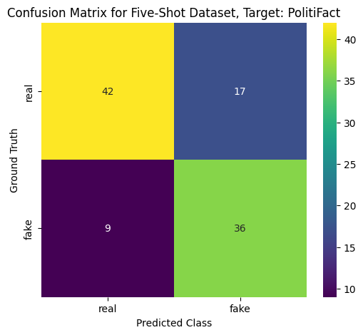

```python
# Train model with optimal hyperparams on five-shot mixed dataset with PolitiFact contributing only 5 samples
five_shot_target_pf_model = trainModel(
    pf_target_five_shot_train_basic_feature_df, # PolitiFact target five-shot training set
    extra_feature_columns, # List of extra feature column names for Column Transformer extraction
    dict(hyperparameter_optimization_results_df.loc["Five_Shot_PolitiFact_Target", "Best Hyperparameters"]) # Pass in best params as dict
)

# Evaluate on PolitiFact validation set
five_shot_target_pf_eval_dict = evaluateModel(five_shot_target_pf_model, pf_val_basic_feature_df, extra_feature_columns,
                                            "Five-Shot Dataset, Target: PolitiFact")
```

```
Training the model...
Model training complete.
Accuracy: 0.3992
Precision (Macro): 0.5590
Recall (Macro): 0.5590
Macro F1-score: 0.3992

Classification Report:

              precision    recall  f1-score   support

           0       0.86      0.26      0.40      2018
           1       0.26      0.86      0.40       612

    accuracy                           0.40      2630
   macro avg       0.56      0.56      0.40      2630
weighted avg       0.72      0.40      0.40      2630
```

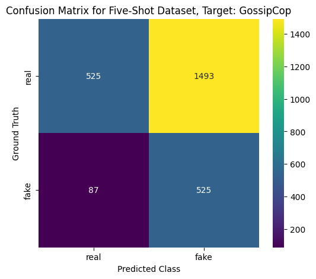

```python
# Train model with optimal hyperparams on five-shot mixed dataset with GossipCop contributing only 5 samples
five_shot_target_gc_model = trainModel(
    gc_target_five_shot_train_basic_feature_df, # GossipCop target five-shot training set
    extra_feature_columns, # List of extra feature column names for Column Transformer extraction
    dict(hyperparameter_optimization_results_df.loc["Five_Shot_GossipCop_Target", "Best Hyperparameters"]) # Pass in best params as dict
)

# Evaluate on GossipCop validation set
five_shot_target_gc_eval_dict = evaluateModel(five_shot_target_gc_model, gc_val_basic_feature_df, extra_feature_columns,
                                                "Five-Shot Dataset, Target: GossipCop")
```

### Zero-Shot Scenario Evaluation (3 Source Combined Datasets for Training, Evaluation on Validation Set from Left-Out Dataset)

```
Training the model...
Model training complete.
Accuracy: 0.6080
Precision (Macro): 0.5928
Recall (Macro): 0.5901
Macro F1-score: 0.5907

Classification Report:

              precision    recall  f1-score   support

           0       0.66      0.69      0.67      5463
           1       0.53      0.49      0.51      3862

    accuracy                           0.61      9325
   macro avg       0.59      0.59      0.59      9325
weighted avg       0.60      0.61      0.61      9325
```

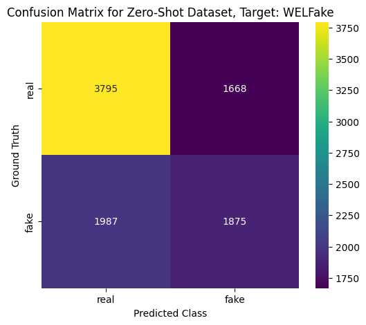

```python
# Train model with optimal hyperparams on zero-shot mixed dataset with zero WELFake samples
zero_shot_target_wf_model = trainModel(
    wf_target_zero_shot_train_basic_feature_df, # WELFake target zero-shot training set
    extra_feature_columns, # List of extra feature column names for Column Transformer extraction
    dict(hyperparameter_optimization_results_df.loc["Zero_Shot_WELFake_Target", "Best Hyperparameters"]) # Pass in best params as dict
)

# Evaluate on WELFake validation set
zero_shot_target_wf_model = evaluateModel(zero_shot_target_wf_model, wf_val_basic_feature_df, extra_feature_columns,
                                             "Zero-Shot Dataset, Target: WELFake")
```

```
Training the model...
Model training complete.
Accuracy: 0.4201
Precision (Macro): 0.3973
Recall (Macro): 0.4347
Macro F1-score: 0.3715

Classification Report:

              precision    recall  f1-score   support

           0       0.36      0.14      0.20      1116
           1       0.44      0.73      0.55      1012

    accuracy                           0.42      2128
   macro avg       0.40      0.43      0.37      2128
weighted avg       0.40      0.42      0.36      2128
```

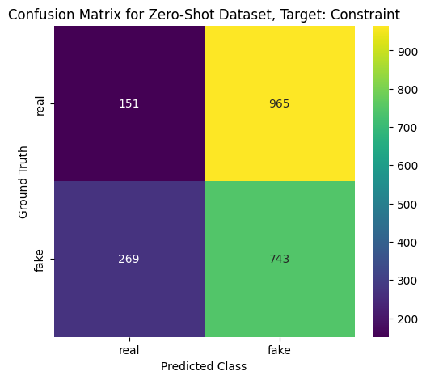

```python
# Train model with optimal hyperparams on zero-shot mixed dataset with zero Constraint samples
zero_shot_target_ct_model = trainModel(
    ct_target_zero_shot_train_basic_feature_df, # Constraint target zero-shot training set
    extra_feature_columns, # List of extra feature column names for Column Transformer extraction
    dict(hyperparameter_optimization_results_df.loc["Zero_Shot_Constraint_Target", "Best Hyperparameters"]) # Pass in best params as dict
)

# Evaluate on Constraint validation set
zero_shot_target_ct_model = evaluateModel(zero_shot_target_ct_model, ct_val_basic_feature_df, extra_feature_columns,
                                         "Zero-Shot Dataset, Target: Constraint")
```

```
Training the model...
Model training complete.
Accuracy: 0.7115
Precision (Macro): 0.7161
Recall (Macro): 0.7194
Macro F1-score: 0.7111

Classification Report:

              precision    recall  f1-score   support

           0       0.80      0.66      0.72        59
           1       0.64      0.78      0.70        45

    accuracy                           0.71       104
   macro avg       0.72      0.72      0.71       104
weighted avg       0.73      0.71      0.71       104
```

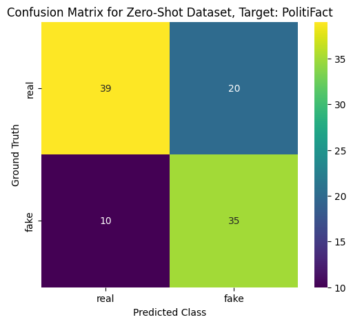

```python
# Train model with optimal hyperparams on zero-shot mixed dataset with zero PolitiFact samples
zero_shot_target_pf_model = trainModel(
    pf_target_zero_shot_train_basic_feature_df, # PolitiFact target zero-shot training set
    extra_feature_columns, # List of extra feature column names for Column Transformer extraction
    dict(hyperparameter_optimization_results_df.loc["Zero_Shot_PolitiFact_Target", "Best Hyperparameters"]) # Pass in best params as dict
)

# Evaluate on PolitiFact validation set
zero_shot_target_pf_model = evaluateModel(zero_shot_target_pf_model, pf_val_basic_feature_df, extra_feature_columns,
                                         "Zero-Shot Dataset, Target: PolitiFact")
```

```
Training the model...
Model training complete.
Accuracy: 0.4167
Precision (Macro): 0.5610
Recall (Macro): 0.5653
Macro F1-score: 0.4164

Classification Report:

              precision    recall  f1-score   support

           0       0.86      0.29      0.43      2018
           1       0.26      0.84      0.40       612

    accuracy                           0.42      2630
   macro avg       0.56      0.57      0.42      2630
weighted avg       0.72      0.42      0.42      2630
```

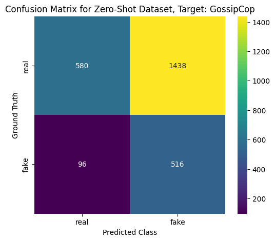

```python
# Train model with optimal hyperparams on zero-shot mixed dataset with zero GossipCop samples
zero_shot_target_gc_model = trainModel(
    gc_target_zero_shot_train_basic_feature_df, # GossipCop target zero-shot training set
    extra_feature_columns, # List of extra feature column names for Column Transformer extraction
    dict(hyperparameter_optimization_results_df.loc["Zero_Shot_GossipCop_Target", "Best Hyperparameters"]) # Pass in best params as dict
)

# Evaluate on GossipCop validation set
zero_shot_target_gc_model = evaluateModel(zero_shot_target_gc_model, gc_val_basic_feature_df, extra_feature_columns,
                                         "Zero-Shot Dataset, Target: GossipCop")
```

## Evaluation Results Following Feature Extraction Techniques

### Results for Full-Scale Evaluation Scenario

| Dataset | Accuracy | Precision (Macro) | Recall (Macro) | Macro F1-score |
| --- | --- | --- | --- | --- |
| WELFake | 0.9635 | 0.9616 | 0.9635 | 0.9625 |
| Fakeddit | 0.8403 | 0.8395 | 0.8356 | 0.8372 |
| Constraint | 0.9464 | 0.9468 | 0.9459 | 0.9463 |
| PolitiFact | 0.8942 | 0.8942 | 0.9015 | 0.8937 |
| GossipCop | 0.8483 | 0.7991 | 0.7503 | 0.7696 |

### Results for Five-Shot Evaluation Scenario

| Dataset Target | Accuracy | Precision (Macro) | Recall (Macro) | Macro F1-score |
| --- | --- | --- | --- | --- |
| WELFake target | 0.6253 | 0.6093 | 0.6024 | 0.6030 |
| Constraint target | 0.4328 | 0.4038 | 0.4496 | 0.3677 |
| PolitiFact target | 0.7500 | 0.7514 | 0.7559 | 0.7492 |
| GossipCop target | 0.3992 | 0.5590 | 0.5590 | 0.3992 |

### Results for Zero-Shot Evaluation Scenario

| Dataset Target | Accuracy | Precision (Macro) | Recall (Macro) | Macro F1-score |
| --- | --- | --- | --- | --- |
| WELFake target | 0.6080 | 0.5928 | 0.5901 | 0.5907 |
| Constraint target | 0.4201 | 0.3973 | 0.4347 | 0.3715 |
| PolitiFact target | 0.7115 | 0.7161 | 0.7194 | 0.7111 |
| GossipCop target | 0.4167 | 0.5610 | 0.5653 | 0.4164 |

## Interpretation of Results Following Feature Extraction and Hyperparameter Tuning

### Full-Scale Evaluation Scenario:

- Slight improvements across F1-score when compared to baseline scores
- WELFake F1-score increased from 94% to 96%
- Fakeddit F1-score increased from 81% to 84%
- Constraint increase in F1-score was minimal (from 93.82% to 94.63%)
- Gossipcop increase from 75% to 77%

### General Interpretations

- Feature extraction and hyperparameter tuning was not successful for few-shot and zero-shot evaluation on the two challenging Constraint and GossipCop datasets, probably due to overfitting/overtuning to the training data which contained few or no samples of the target dataset
- Better generalizability between WELFake and PolitiFact may be attributed to the fact that data samples come from the same domain (topic), i.e. political news and general current affairs, while Constraint contains health news and GossipCop entertainment news
- As a result, extensive hyperparameter tuning may not be ideal in a few-shot and zero-shot scenario due to overtuning to the training set
- Shows the challenge of using traditional machine-learning models for generalization across domains/news topics